# WGOA Survey Stations

Jesse F Lamb

2024-01-09

## Overview:

This work is for planning of the DY23-07 Spring Larval Survey in the Western Gulf of Alaska (WGOA). The survey has been allotted 12 days at sea (DAS), beginning from Dutch Harbor, AK and ending in Kodiak, AK. The first maps will focus on the most relevant spatial regions, due to prior years sampling. The subsequent maps will delve into the most efficient cruise tracks give our limited DAS compared to previous years (21 DAS).

```r
#Install Packages
ipak <- function(pkg){
  new.pkg <- pkg[!(pkg %in% installed.packages()[, "Package"])]
  if (length(new.pkg))
    install.packages(new.pkg, dependencies = TRUE)
  sapply(pkg, require, character.only = TRUE)
}

packages <- c("tidyr",  "dplyr","lubridate","hms", "ggplot2", "ggmap", "lattice", "stringr", "data.table",  "tibble","readxl", "sf","maps", "mapdata", "mapplots", "mapview", "marmap", "Cairo", "ncdf4", "oce", "here","reshape2", "viridis", "export", "rnaturalearth",  "rnaturalearthdata", "forcats","sf", "geosphere")
ipak(packages)
```

```
##             tidyr             dplyr         lubridate               hms
##              TRUE              TRUE              TRUE              TRUE
##           ggplot2             ggmap           lattice           stringr
##              TRUE              TRUE              TRUE              TRUE
##        data.table            tibble            readxl                sf
##              TRUE              TRUE              TRUE              TRUE
##              maps           mapdata          mapplots           mapview
##              TRUE              TRUE              TRUE              TRUE
##            marmap             Cairo             ncdf4               oce
##              TRUE              TRUE              TRUE              TRUE
##              here          reshape2           viridis            export
##              TRUE              TRUE              TRUE              TRUE
##     rnaturalearth rnaturalearthdata           forcats                sf
##              TRUE              TRUE              TRUE              TRUE
##         geosphere
##              TRUE
```

```r
# Create Base Layer Maps will all numbered stations labeled, with a more focused region (not whole WGOA)
world <- ne_countries(scale = "medium", returnclass = "sf")
class(world)
```

```
## [1] "sf"         "data.frame"
```

```r
# Read in "late-larval core" region used for larval time-series, as shapefile:
# convert to Lat/lon projection.
shp.mp <- read_sf(dsn=here("Data","mapping_data","NewLateLarvalPolygon"),layer="Survey_poly")
#shp.mp.LL<-st_transform(shp.mp,CRS("+proj=longlat"))
shp.mp.LL<-st_transform(shp.mp,crs=("+proj=longlat"))

WGOAdata <- read.csv(here("Data","WGOA station_list_dougherty_2019_ProjInstrutions.csv"))

GridStaData <- read.csv(here("Data","2023-10-18 WGOA Grid Sta Depth Data.csv"))
GridMeanZ <- GridStaData %>% group_by(FOCI_GRID) %>% summarise(MeanZ = mean(BOTTOM_DEPTH)) %>%
  dplyr::rename("Grid.ID"="FOCI_GRID")

# If using "WGOA station_list_dougherty_2019_ProjInstrutions.csv" as WGOAdata, run the following
WGOAdata <- WGOAdata %>% rename("LAT" = "Latitude.N.") %>% rename("LON"="Longitude..W.")
WGOAdata$LON <- WGOAdata$LON*-1

# Count Gear.Sampled
table(WGOAdata$Gear.Sampled)
```

```
##
##                  CALVET CALVET, CTD         CTD         NEU    NEU, CTD
##         144          20           5          14          88           1
```

```r
# get bathymetry data
b = getNOAA.bathy(lon1 = -166, lon2 = -140, lat1 = 52, lat2 = 62,
                  resolution = 15)
## Querying NOAA database ...
## This may take seconds to minutes, depending on grid size
## Building bathy matrix ...
# convert bathymetry to data frame
bf = fortify.bathy(b)
# get regional polygons
reg = map_data("world2Hires")
reg = subset(reg, region %in% c('USSR', 'USA'))
# convert lat longs
reg$long = (360 - reg$long)*-1
# set map limits, whole region
lons = c(-167, -149) #-140 = large map
lats = c(53, 60.25) # 52 = large map

######################################
# make plot
GOARegion_Map_New <- ggplot()+
   # add 50m contour
  geom_contour(data = bf, aes(x=x, y=y, z=z),breaks=c(-50),linewidth=c(0.5),colour="light grey")+
  # add 100m contour
  geom_contour(data = bf, aes(x=x, y=y, z=z),breaks=c(-100),linewidth=c(0.5),colour="darkgrey")+
  # add 200m contour
  geom_contour(data = bf, aes(x=x, y=y, z=z),breaks=c(-200),linewidth=c(0.5),colour="black")+

  # add late larval "core" polygon
 # geom_sf(data = shp.mp.LL, color="green", fill=NA, linewidth = 1.5) +
  # add coastline
  geom_sf(data = world)+
  coord_sf(xlim = lons, ylim = lats, expand = FALSE)+
  #Plot WGOA points
  geom_point(data = WGOAdata, mapping = aes(Longitude..W., Latitude.N., shape = Gear.Sampled),
             size = 1, show.legend = FALSE)+
  #Delete "shape..." for just stations
  geom_text(data = WGOAdata, mapping = aes(Longitude..W., Latitude.N., label = Station ),
            nudge_y = -0.08, size = 2.5)+
  #station text size & nudge NOT IN 'aes' configure projection and plot domain coord_map(xlim = lons, ylim = lats)+

  # formatting
  scale_shape_discrete()+
  theme_bw()+
  xlab("Longitude")+
  ylab("Latitude")+
  theme(axis.text.x=element_text(size=10, color = "black"), axis.text.y = element_text(size=10, color = "black"))

 #GOARegion_Map_New

#ggsave("SpringLarval_AllSTA_2023_Gear&StationNo.png",path = here("Docs"), height = 8.5, width = 11, units = "in")
```

```r
### Create Station & Runtime Dataset, mirroring "Final Station Runtime" Spreadsheets

# Filter out Stations
# LLC = "late larval core" from polygon plot above
#LLCvec <- c(0,60:225,271)
AllSTA <- WGOAdata$Station #See line 202 below
#Scen1<-c(0,24:28,44:38,53:59,60:179, 180, 181,201:197,208:213, 216,218,220,228:225,
#         234:238,239, 245:243,249:251,257:255,261:263, 269:267,271)

ScenName <- "All Possible Stations from DY19-05"
Scenario<-AllSTA
FinalSta<-data.frame("Station"=Scenario,"Stn_Order"=1:length(Scenario))

# Station Selection Through Omission (Example Below)

# AllSta <- c(0:271) # All Possible Stations
# OmitSta <- c(0,60:225,271) # Stations to leave out
# FinalSta <- setdiff(AllSta,LLCvec) # All stations left
Sta <- WGOAdata %>% left_join(.,FinalSta) %>%
  filter(Station %in% FinalSta$Station) %>%
  arrange(Stn_Order) %>% mutate(Grid.ID = toupper(Grid.ID))


Sta <- Sta %>% left_join(.,GridMeanZ, by = "Grid.ID")


# 1. Create data.frame that mirrors "Final Station Runtime"
SRTdata <- Sta %>% #rename(LAT = Latitude.N., LON = Longitude..W.) %>%
  mutate(Gear.Sampled = replace(Gear.Sampled,Gear.Sampled == "","BONGO")) %>%
  mutate(Gear.Sampled = replace(Gear.Sampled,Gear.Sampled == "NEU","BONGO")) %>%
  mutate(Gear.Sampled =  replace(Gear.Sampled,Gear.Sampled == "NEU, CTD","BONGO,CTD")) %>%
  mutate(Gear.Sampled = replace(Gear.Sampled,Gear.Sampled == "CTD","BONGO,CTD")) %>%
  mutate(Gear.Sampled = replace(Gear.Sampled,Gear.Sampled == "CALVET","BONGO,CALVET")) %>%
  mutate(Gear.Sampled = replace(Gear.Sampled,Gear.Sampled == "CALVET, CTD","BONGO,CALVET,CTD")) %>%
  mutate(Bongo_hrs = ifelse(Gear.Sampled == "BONGO", 0.33,0)) %>% # BONGO at all stations
  mutate(BON_CTD_hrs = ifelse(Gear.Sampled == "BONGO,CTD",0.83,0)) %>%
  mutate(BON_CalVET_hrs = ifelse(Gear.Sampled == "BONGO,CALVET", 0.66,0)) %>%
  mutate(BON_Cal_CTD_hrs = ifelse(Gear.Sampled == "BONGO,CALVET,CTD",1.16,0)) %>%
#<<<<<<< Updated upstream
  mutate(Station_Time = lubridate::dhours(rowSums(across(c(Bongo_hrs,BON_CTD_hrs,BON_CalVET_hrs,BON_Cal_CTD_hrs))))) %>% mutate(Ship_Speed = 11) %>% # Ship speed is Variable
  mutate(lat_rad = LAT*pi/180) %>% mutate(long_rad = LON*pi/180) %>%
  mutate(long_dif = long_rad - shift(long_rad)) %>%
#>>>>>>> Stashed changes
  mutate(Dist_NM = ifelse(Station == 0,0,0) ) %>%
  mutate(Dist_NM = distGeo(cbind(LON,LAT),cbind(shift(LON),shift(LAT)))/(1000*1.852)) %>% # distGEO does what code below does in base
#  mutate(Dist_NM = acos((sin(lag(lat_rad))*sin(lat_rad))+(cos(lag(lat_rad))*cos(lat_rad)*cos(long_dif)))/(pi/180)*60) %>%
  mutate(Steam_T = Dist_NM/Ship_Speed) %>%
  mutate(Steam_T = lubridate::dhours(Steam_T))

# 2. rearrange data to calculate time to travel to and complete station operations
shipslog <- SRTdata %>% select(Station, Grid.ID,Station_Time, Steam_T, Stn_Order) %>% # SRTdata will be replaced by filtered stations above
  unite("Station",Station:Grid.ID, sep = "_", remove = FALSE) %>%
  select(Station,Steam_T,Station_Time,Stn_Order) %>%
  gather(key="Ops", Time_Dur, -Station,-Stn_Order) %>% arrange(Station) %>%
  separate(Station, c("Station","Grid.ID"), sep = "_") %>%
  transform(Station = as.numeric(Station)) %>% arrange(Stn_Order)
shipslog <- na.omit(shipslog)
# 3. Choose Departure Date
depart <- ymd_hm("2023-05-14 12:00")
# 4. Create a table of Station Completion Times
ShipsLog <- shipslog %>% group_by(Stn_Order, Station, Grid.ID) %>%
  reframe(Time_Dur = lubridate::dseconds(sum(Time_Dur)))  %>%
  mutate(Sta_Time =  depart) %>% mutate(cTime_Dur = cumsum(Time_Dur)) %>%
  mutate(Sta_Time = cTime_Dur + Sta_Time) %>% select(Station, Stn_Order, Grid.ID,Sta_Time)

# 5. Plot filtered station map with survey track
StaMapF <-ggplot()+geom_contour(data = bf, aes(x=x, y=y, z=z),breaks=c(-50),linewidth=c(0.5),colour="light grey")+ # add 50m contour
  geom_contour(data = bf, aes(x=x, y=y, z=z), breaks=c(-100), linewidth=c(0.5), colour="darkgrey")+ # add 100m contour
  geom_contour(data = bf, aes(x=x, y=y, z=z),breaks=c(-200),linewidth=c(0.3), colour="black")+ # add 200m contour
  geom_sf(data = world)+coord_sf(xlim = lons, ylim = lats, expand = FALSE)+ # add coastline
  #Plot points & station track
  geom_point(data = SRTdata, mapping = aes(LON, LAT, shape = Gear.Sampled), size = 1)+
  geom_path(data = SRTdata, mapping = aes(LON, LAT), linewidth = 0.25) +
  geom_text(data = SRTdata, mapping = aes(LON, LAT, label = Station ), nudge_y = -0.08, size = 2.5)+
  scale_shape_discrete()+ theme_bw()+xlab("Longitude")+ylab("Latitude")+ ggtitle(paste(ScenName,length(Scenario),"Stns")) +
  theme(axis.text.x=element_text(size=10, color = "black"), axis.text.y = element_text(size=10, color = "black"))

#StaMapF

#ggsave(paste0(ScenName,".png"),path = here("Docs"), height = 8.5, width = 11, units = "in")
```

Create Station Table file from “SRTdata” above, with a column listing station sampling priority: “A” = high, “B” = moderate, “C” = low. This will allow easy filtering at sea if/when we lose time for expedient decision making.

```r
# Create table, remove all CTDs not part of transects; create "A,B,C" station vectors
# Note: Station 0 = Dutch Harbor, 271 = Kodiak Pier

# Below is an EXAMPLE to get code to run and plot proper (4/27/23)
A <- c(0,24:28, 53:59, 77:84,93:100,108:113,120:125,132:141,148:152,160:165,
       167,169,171,173,175,177,208:213,225:228,220,218,216,234:238,271)
B <- c(1:9, 38:44,68:76,85:92,101:107,114:119,126:131,142:147,153:159,166,168,170,
       172,174,176,179:181,201,199,197,224:221,219,217,215,214,229:233,239,243:245,
       249:251,255:257,261:263,267:269)
Port <-c(0,271)
# C = anything not A & B, see line 200 below


WGOA_StaTable <- SRTdata %>% select(Station, Grid.ID,LAT,LON,Gear.Sampled) %>%
  mutate(Gear.Sampled = ifelse(Station == 24,"BONGO",Gear.Sampled)) %>%
  mutate(Gear.Sampled = ifelse(Station == 40,"BONGO",Gear.Sampled)) %>%
  mutate(Gear.Sampled = ifelse(Station == 94,"BONGO",Gear.Sampled)) %>%
  mutate(Gear.Sampled = ifelse(Station %in% Port,"",Gear.Sampled)) %>%
  mutate(Sta_Pri = if_else(Station %in% A,"A",if_else(Station %in% B,"B","C")))

# Remove C priority Stations
WGOA_StaTable <- WGOA_StaTable %>% filter(Sta_Pri != "C")
ScenName <- "DY23-07 All A & B Priority Stations"

write.csv(WGOA_StaTable, here("Data","DY23-07_A&B_priority.csv"))
```

## Station Priority Map

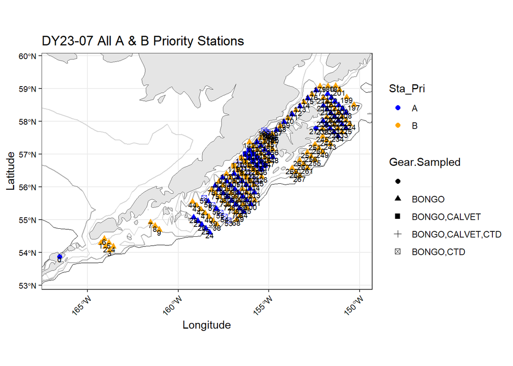